# Visualizing Data

CIS 241, Dr. Ladd

`spacebar` to go to the next slide, `esc`/menu to navigate

# Why Do We Visualize Data?

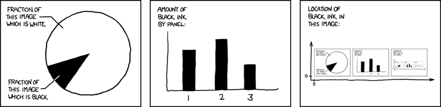

xkcd.com/688

## Visualization can be *exploratory*, *explanatory*, or both!

- Exploratory viz helps *us* (the researchers or analysts) understand the data.
- Explanatory viz helps *others* (the clients or audience) understand our analysis.
- Many visualizations do both of these things at once!

## Some Good Resources on Visualization

- Claus Wilke’s [Fundamentals of Data Visualization](https://clauswilke.com/dataviz/) (The illustrations in this slide show come from here!)
- [The Altair User Guide](https://altair-viz.github.io/user_guide/data.html)
- [Visualization Curriculum for Altair](https://idl.uw.edu/visualization-curriculum/intro.html)

# What Does Visualization Help Us to See?

## Viz Can Help Us See *Amounts*.

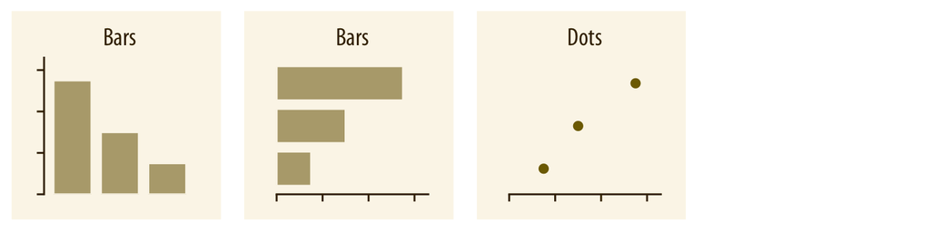

Graph a single value across one set of categories.

- Variable types: 1 categorical and 1 numerical
- Common graph types: Bar plot (Don’t confuse the dot plot with the scatter plot!)

## Plot *Amounts* With Multiple Categories.

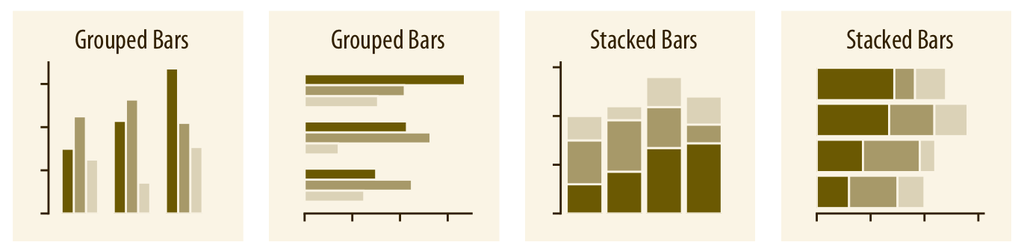

- Variable types: 2 or more categorical, 1 numerical
- Common graph types: Grouped or stacked bar, heat map

## Viz Can Help Us See *Distributions*.

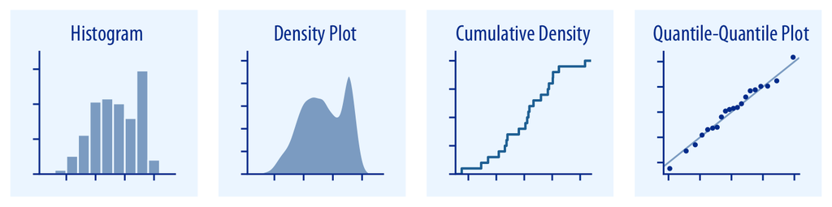

Graph a distribution of a single variable.

- Variable type: 1 continuous (numerical)
- Common graph types: Histograms, Density plots, Q-Q plots

## *Distributions* with Multiple Categories.

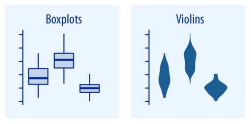

- Variable types: 1 continuous (numerical), 1 categorical
- Common graph types: Box plots, Violin plots

## You Try It!

Look at the `taxis` data set. What visualization type would you use to compare the counts of each destination Borough? Which variables would you use, and what *kind* of variables are they? Jot down your answers.

## Viz Can Help Us See *Proportions*.

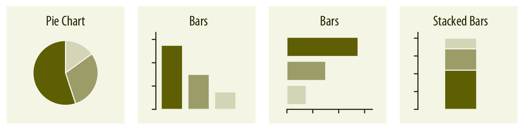

- Variable types: 1 numerical, 1 categorical
- Common graph types: Pie chart, Bar plot

## Viz Can Help Us See *Relationships*.

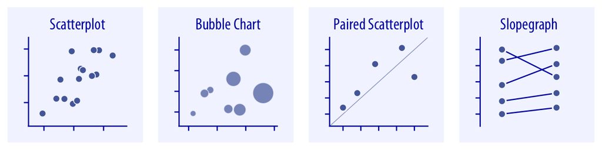

- Variable types: 2 continuous (numerical), (3 in a bubble chart)
- Common graph types: Scatter plot, Bubble Chart, Line plot, Hex bins, Density contours

## You Try It!

Look at the `taxis` data again. What visualization type would you use to compare the distribution of tips among different taxi colors? Which variables would you use, and what *kind* of variables are they? Jot down your answers.

## Viz Helps Us See *Time*, *Location*, *Uncertainty*…

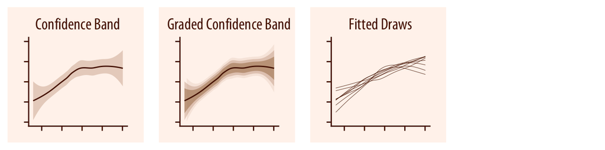

Confidence bands are an example of visualized uncertainty.

More on these viz types in future lessons!

# Make Great Viz with `Altair`

## Altair is *declarative*.

- You use the Grammar of Graphics approach to *declare* the parts of the visualization.
- Focus on *what you want to show* rather than how to make it appear.
- Builds on [Vega-Lite](https://vega.github.io/vega-lite/), works similarly to [ggplot2](https://ggplot2.tidyverse.org/) and [Tableau](https://www.tableau.com/why-tableau/what-is-tableau)

## Importing Altair

```python
import altair as alt
alt.data_transformers.enable("vegafusion")
```

In addition to importing, use the [VegaFusion Data Transformer](https://altair-viz.github.io/user_guide/large_datasets.html#vegafusion-data-transformer) for large datasets.

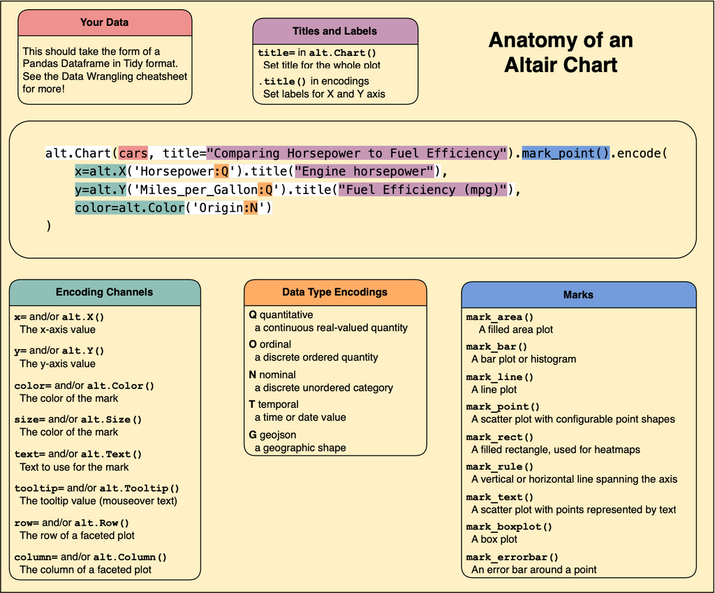

## You Try It!

Use the Altair Cheatsheet to create a plot comparing the high temperature in Seattle to the wind speed using the `seattle_weather` DataFrame. Then create the same plot but show color as the type of weather.

```python
from vega_datasets import data

seattle_weather = data.seattle_weather()
```

If this is hard to read, you might also show the types of weather as separate *columns*.

## You Try It!

Create a plot showing the distribution of precipitation in the `seattle_weather` dataset. Give the plot a title and labels for both axes. Then show the distributions according to each type of weather, in different columns. Finally, change the size or number of the bins in each distribution to show more detail (narrower bars).

Hint: you may need to use the [Altair User Guide](https://altair-viz.github.io/user_guide/data.html) as well as the cheatsheet, our Altair Guide, and the Visualization Curriculum to accomplish this!

# Ugly, Bad, or Wrong

[figure not shown]

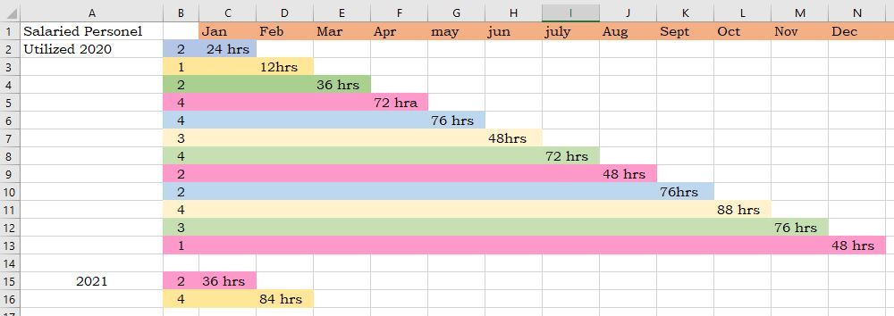

[figure not shown]

[figure not shown]

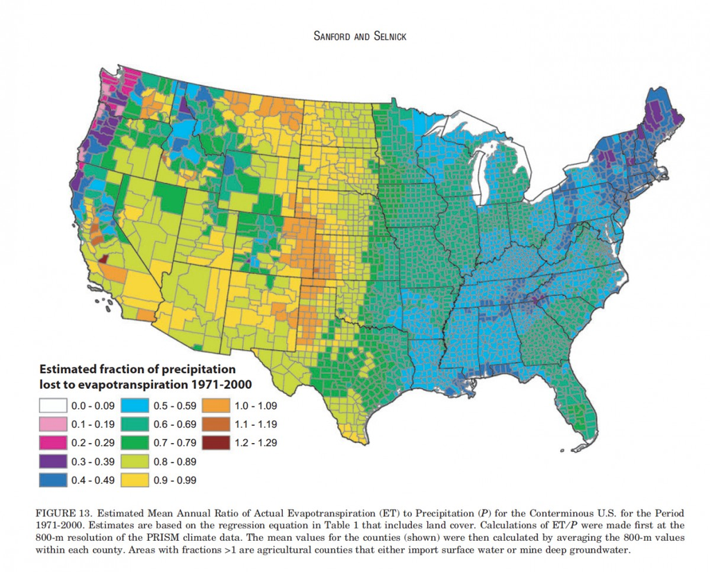

[figure not shown]

## More Examples of Bad Viz

[viz.wtf](https://viz.wtf/)

[r/dataisugly](https://www.reddit.com/r/dataisugly/)